# Nematode Diversity standardized by 100 individuals

Wei, C.-L., Liao, J.-X.

2019-09-29

# Reguired package

```r
library(nema)
library(iNEXT)
library(ggplot2)
library(reshape2)
library(vegan)
library(plyr)
library(viridis)
library(doBy)
library(cowplot)
library(knitr)
library(nlme)
```

# ggplot theme setting

```r
large <- theme(legend.title = element_text(size=15),
        legend.text = element_text(size=15),
        axis.title = element_text(size=15),
        axis.text = element_text(size=15),
        strip.text = element_text(size=15))

rotate <- theme(axis.text.x = element_text(angle = 30, hjust=0.5))

no_strip <- theme(strip.background = element_rect(colour=NA, fill=NA),
                  strip.text = element_text(colour=NA))
```

# Preparing nematode and environmental data

Relative abundance of nematode species from 100 randomly slected individuals was scaled to the total nematode abundance in each sample.

```r
# Convert to species-by-sample matrix
b <- acast(nema_abund, Cruise+Station+Deployment+Tube+Subcore~Genus+Species, fill=0)
# Multiply the relative abundance by total abundance
#b <- ceiling(decostand(b, "total")*nema_total$Abundance)

# Match environmental data to neamtode sample
e <- ldply(strsplit(row.names(b), split="_"))
e <- cbind(with(e, paste(V1, V2, sep="_")), e[,-1:-2])
names(e) <- c("Cruise", "Station", "Deployment", "Tube", "Subcore")
id1 <- with(e, paste(Cruise, Station, Deployment))
id2 <- with(nema_cruise, paste(Cruise, Station, Deployment))
e <- cbind(e, nema_cruise[match(id1, id2), -3:-5])

# Define depth zone
depth.bk <- c(200, 400, 600, 800, 1100)
depth.lab <- c("200-400", "400-600", "600-800", "800-1100")
e$Zone <- cut(e$Depth, breaks=depth.bk, labels=depth.lab)

# Match the trait data to the species-by-sample matrix
s <- nema_species[match(colnames(b), with(nema_species, paste(Genus, Species, sep="_"))),]
```

# Abundance

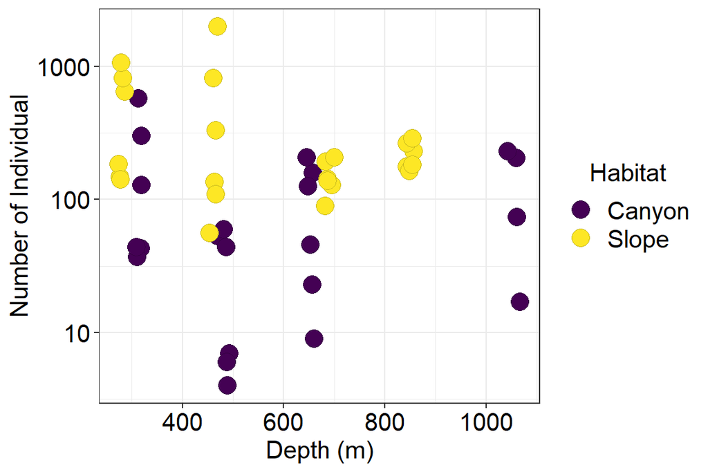

```r
ggplot(data=cbind(Abund=nema_total$Abundance, e),
       aes(x=Depth, y=Abund, colour=Habitat))+
  geom_point(aes(fill=Habitat), pch=21, colour=gray(0, 0.2), size=5,
                  position=position_jitter(width=10))+
  labs(x="Depth (m)", y="Number of Individual")+
  scale_fill_viridis(discrete = TRUE)+
  scale_color_viridis(discrete = TRUE)+
  scale_y_log10()+
  theme_bw() %+replace% large
```

```r
# Linear regression
hl <- splitBy(~Habitat, cbind(Abund=nema_total$Abundance, e))
lapply(hl, FUN=function(x)summary(lm(log10(Abund)~Depth, data=x)))
```

```
## $Canyon
##
## Call:
## lm(formula = log10(Abund) ~ Depth, data = x)
##
## Residuals:
##     Min      1Q  Median      3Q     Max
## -1.1063 -0.3078 -0.0109  0.4568  1.0763
##
## Coefficients:
##              Estimate Std. Error t value Pr(>|t|)
## (Intercept) 1.6341020  0.3236969   5.048 6.15e-05 ***
## Depth       0.0001524  0.0005049   0.302    0.766
## ---
## Signif. codes:  0 '***' 0.001 '**' 0.01 '*' 0.05 '.' 0.1 ' ' 1
##
## Residual standard error: 0.5994 on 20 degrees of freedom
## Multiple R-squared:  0.004536,   Adjusted R-squared:  -0.04524
## F-statistic: 0.09113 on 1 and 20 DF,  p-value: 0.7659
##
##
## $Slope
##
## Call:
## lm(formula = log10(Abund) ~ Depth, data = x)
##
## Residuals:
##      Min       1Q   Median       3Q      Max
## -0.67963 -0.26824 -0.00042  0.20776  0.87025
##
## Coefficients:
##               Estimate Std. Error t value Pr(>|t|)
## (Intercept)  2.6715942  0.2066284  12.929 9.37e-12 ***
## Depth       -0.0005277  0.0003390  -1.557    0.134
## ---
## Signif. codes:  0 '***' 0.001 '**' 0.01 '*' 0.05 '.' 0.1 ' ' 1
##
## Residual standard error: 0.3605 on 22 degrees of freedom
## Multiple R-squared:  0.09922,    Adjusted R-squared:  0.05827
## F-statistic: 2.423 on 1 and 22 DF,  p-value: 0.1338
```

```r
# Linear Mixed-Effects Models
f <- lme(fixed = log10(Abund) ~ Habitat*Depth, random = ~1|Cruise, data=cbind(Abund=nema_total$Abundance, e), method = "REML", weights=varIdent(form=~1|Cruise))
summary(f)
```

```
## Linear mixed-effects model fit by REML
##  Data: cbind(Abund = nema_total$Abundance, e)
##        AIC      BIC    logLik
##   102.1094 114.2731 -44.05468
##
## Random effects:
##  Formula: ~1 | Cruise
##          (Intercept)  Residual
## StdDev: 3.496759e-05 0.2890627
##
## Variance function:
##  Structure: Different standard deviations per stratum
##  Formula: ~1 | Cruise
##  Parameter estimates:
## OR1_1114 OR1_1126
## 1.000000 2.524732
## Fixed effects: log10(Abund) ~ Habitat * Depth
##                         Value  Std.Error DF   t-value p-value
## (Intercept)         2.0063806 0.19639775 41 10.215904  0.0000
## HabitatSlope        0.2006568 0.29346483 41  0.683751  0.4980
## Depth               0.0000416 0.00029216 41  0.142463  0.8874
## HabitatSlope:Depth -0.0000646 0.00046186 41 -0.139797  0.8895
##  Correlation:
##                    (Intr) HbttSl Depth
## HabitatSlope       -0.669
## Depth              -0.917  0.613
## HabitatSlope:Depth  0.580 -0.926 -0.633
##
## Standardized Within-Group Residuals:
##         Min          Q1         Med          Q3         Max
## -1.95201291 -0.62398144  0.01199247  0.54604038  2.55756015
##
## Number of Observations: 46
## Number of Groups: 2
```

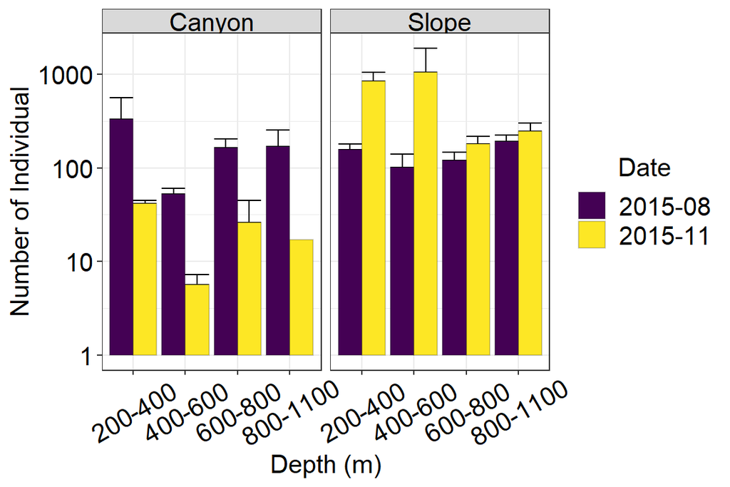

```r
out <- summaryBy(Abund~Cruise+Station+Habitat+Zone, data=cbind(Abund=nema_total$Abundance, e), FUN=c(mean, sd))
out$Date <- factor(out$Cruise, labels=c("2015-08", "2015-11"))
names(out)[5:6] <- c("Abund", "sd")

ggplot(data=out, aes(x=Zone, y=Abund, ymin=Abund, ymax=Abund+sd, fill=Date))+
  geom_errorbar(position="dodge")+
  geom_bar(stat="identity", position="dodge", colour=gray(0, 0.2))+
  facet_wrap(~Habitat)+
  labs(x="Depth (m)", y="Number of Individual")+
  scale_fill_viridis(discrete = TRUE)+
  scale_color_viridis(discrete = TRUE)+
  scale_y_log10()+
  theme_bw() %+replace% large %+replace% theme(axis.text.x=element_text(angle=30))
```

# Estimate Hill Numbers

- Bootstrap confidence interval (1000 iterations)

```r
q0 <- iNEXT(t(b), q = 0, size=1:200, nboot=1000)
q1 <- iNEXT(t(b), q = 1, size=1:200, nboot=1000)
q2 <- iNEXT(t(b), q = 2, size=1:200, nboot=1000)
save(list=c("q0", "q1", "q2"), file="../rda/HillNumbers.rda")
```

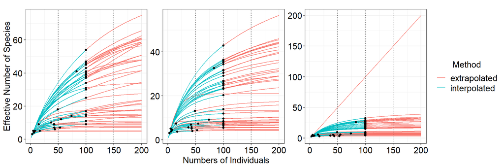

```r
load("../rda/HillNumbers.rda")

h <- rbind(ldply(q0$iNextEst, .id="Sample"),
           ldply(q1$iNextEst, .id="Sample"),
           ldply(q2$iNextEst, .id="Sample"))

ggplot()+
  geom_line(data= subset(h, method!="observed"),
            aes(x=m, y=qD, colour=method, group=Sample))+
  geom_point(data= subset(h, method=="observed"),
             aes(x=m, y=qD, group=Sample))+
  geom_vline(xintercept = c(50, 100, 150), linetype=3)+
  facet_wrap(~order, scale="free")+
  labs(x = "Numbers of Individuals", y = "Effective Number of Species",
       colour="Method")+
  theme_bw()%+replace% large %+replace% no_strip
```

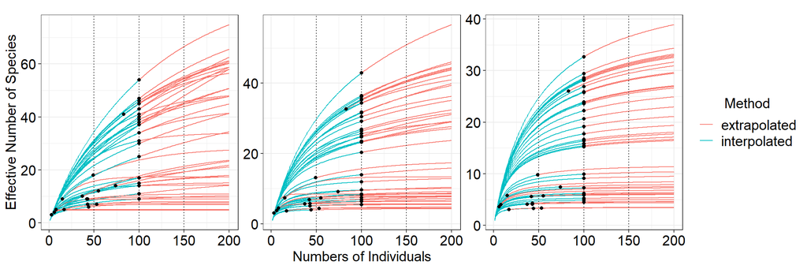

```r
h <- subset(h, !(order==2 & Sample == "OR1_1126_GC2_1_9_2" | Sample == "OR1_1126_GC2_1_9_3"))

ggplot()+
  geom_line(data= subset(h, method!="observed"),
            aes(x=m, y=qD, colour=method, group=Sample))+
  geom_point(data= subset(h, method=="observed"),
             aes(x=m, y=qD, group=Sample))+
  geom_vline(xintercept = c(50, 100, 150), linetype=3)+
  facet_wrap(~order, scale="free")+
  labs(x = "Numbers of Individuals", y = "Effective Number of Species",
       colour="Method")+
  theme_bw()%+replace% large %+replace% no_strip
```

Fig. X. Size-based diversity accumulation curves based on species richness (left), exponential Shannon (middle) and inversed Simpson indices (right). The blue lines indicate the interpolated (rarefied) and red lines indicate extrapolated parts of the accumulation curves based on 1000 permutations. Dotted symbols indicate the observed diversity values. The Hill numbers of order q = 2 (inversed Simpson) for sample “OR1_1126_GC2_1_9_2” and “OR1_1126_GC2_1_9_3” can not be properly estimated and thus were eliminated.

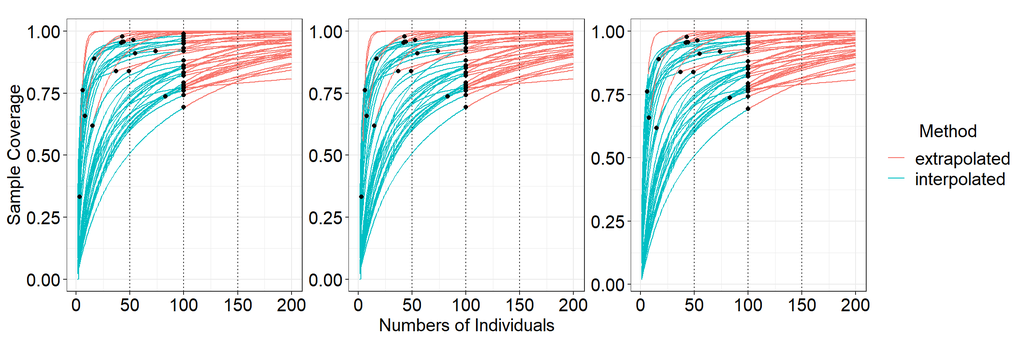

```r
ggplot()+
  geom_line(data= subset(h, method!="observed"),
            aes(x=m, y=SC, colour=method, group=Sample))+
  geom_point(data= subset(h, method=="observed"),
             aes(x=m, y=SC, group=Sample))+
  geom_vline(xintercept = c(50, 100, 150), linetype=3)+
  facet_wrap(~order, scale="free")+
  labs(x = "Numbers of Individuals", y = "Sample Coverage",
       colour="Method")+
  theme_bw()%+replace% large %+replace% no_strip
```

Fig. X. Sample coverage based on species richness (left), exponential Shannon (middle) and inversed Simpson indices (right). The blue lines indicate the interpolated (rarefied) and red lines indicate extrapolated parts of the accumulation curves based on 1000 permutations. Dotted symbols indicate the observed diversity values. The Hill numbers of order q = 2 (inversed Simpson) for sample “OR1_1126_GC2_1_9_2” and “OR1_1126_GC2_1_9_3” can not be properly estimated and thus were eliminated.

```r
# Minimum sample coverage for each order q
min(ldply(lapply(splitBy(~order+Sample, subset(h, order==0)), FUN=function(x)x[dim(x)[1],]))$SC)
```

```
## [1] 0.807
```

```r
min(ldply(lapply(splitBy(~order+Sample, subset(h, order==1)), FUN=function(x)x[dim(x)[1],]))$SC)
```

```
## [1] 0.807
```

```r
min(ldply(lapply(splitBy(~order+Sample, subset(h, order==2)), FUN=function(x)x[dim(x)[1],]))$SC)
```

```
## [1] 0.807
```

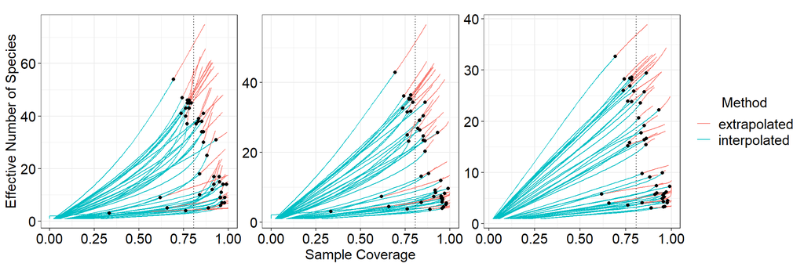

```r
# SC = 0.807

ggplot()+
  geom_line(data= subset(h, method!="observed"),
            aes(x=SC, y=qD, colour=method, group=Sample))+
  geom_point(data= subset(h, method=="observed"),
             aes(x=SC, y=qD, group=Sample))+
  geom_vline(xintercept = c(0.807), linetype=3)+
  facet_wrap(~order, scale="free")+
  labs(x = "Sample Coverage", y = "Effective Number of Species",
       colour="Method")+
  theme_bw()%+replace% large %+replace% no_strip
```

Fig. X. Coverage-based Diversity accumulation curves based on species richness (left), exponential Shannon (middle) and inversed Simpson indices (right) from surface. The blue lines indicate the interpolated (rarefied) and red lines indicate extrapolated parts of the accumulation curves based on 1000 permutations. Dotted symbols indicate the observed diversity values. The vertical dashed line (80.7%) shows the sample with the lowest sample coverage. The Hill numbers of order q = 2 (inversed Simpson) for sample “OR1_1126_GC2_1_9_2” and “OR1_1126_GC2_1_9_3” can not be properly estimated and thus were eliminated.

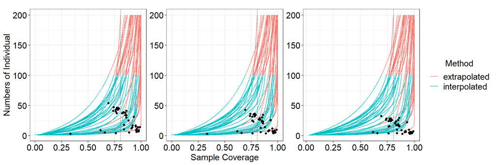

```r
ggplot()+
  geom_line(data= subset(h, method!="observed"),
            aes(x=SC, y=m, colour=method, group=Sample))+
  geom_point(data= subset(h, method=="observed"),
             aes(x=SC, y=qD, group=Sample))+
  geom_vline(xintercept = c(0.807), linetype=3)+
  facet_wrap(~order, scale="free")+
  labs(x = "Sample Coverage", y = "Numbers of Individual",
       colour="Method")+
  theme_bw()%+replace% large %+replace% no_strip
```

Fig. X. Sample size as a function of sample coverage based on species richness (left), exponential Shannon (middle) and inversed Simpson indices (right) from surface. The blue lines indicate the interpolated (rarefied) and red lines indicate extrapolated parts of the accumulation curves based on 1000 permutations. Dotted symbols indicate the observed diversity values. The vertical dashed line (80.7%) shows the sample with the lowest sample coverage. The Hill numbers of order q = 2 (inversed Simpson) for sample “OR1_1126_GC2_1_9_2” and “OR1_1126_GC2_1_9_3” can not be properly estimated and thus were eliminated.

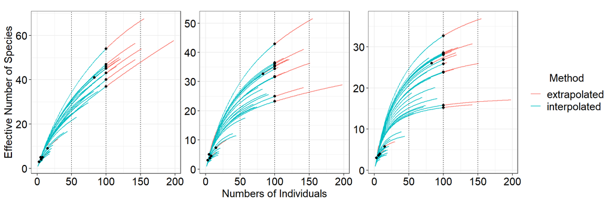

```r
# ~80.7% sample coverage
h0 <- lapply(q0$iNextEst, FUN=function(x) {
  d<-abs(x$SC-0.807)
  x[1:which(d==min(d)),]
  }) %>% ldply(.id="Sample")

h1 <- lapply(q1$iNextEst, FUN=function(x) {
  d<-abs(x$SC-0.807)
  x[1:which(d==min(d)),]
  }) %>% ldply(.id="Sample")

h2 <- lapply(q2$iNextEst, FUN=function(x) {
  d<-abs(x$SC-0.807)
  x[1:which(d==min(d)),]
  }) %>% ldply(.id="Sample")

h <- rbind(h0, h1, h2)
h <- subset(h, !(order==2 & Sample == "OR1_1126_GC2_1_9_3"))

ggplot()+
  geom_line(data= subset(h, method!="observed"),
            aes(x=m, y=qD, colour=method, group=Sample))+
  geom_point(data= subset(h, method=="observed"),
             aes(x=m, y=qD, group=Sample))+
  geom_vline(xintercept = c(50, 100, 150), linetype=3)+
  facet_wrap(~order, scale="free")+
  labs(x = "Numbers of Individuals", y = "Effective Number of Species",
       colour="Method")+
  theme_bw()%+replace% large %+replace% no_strip
```

Fig. X. Size-based diversity accumulation curves based on species richness (left), exponential Shannon (middle) and inversed Simpson indices (right). The blue lines indicate the interpolated (rarefied) and red lines indicate extrapolated parts of the accumulation curves based on 1000 permutations. Dotted symbols indicate the observed diversity values. Sample size (numbers of individuals) and the Hill numbers are cut off by 80.7% sample coverage. The Hill numbers of order q = 2 (inversed Simpson) for sample “OR1_1126_GC2_1_9_3” can not be properly estimated and thus were eliminated.

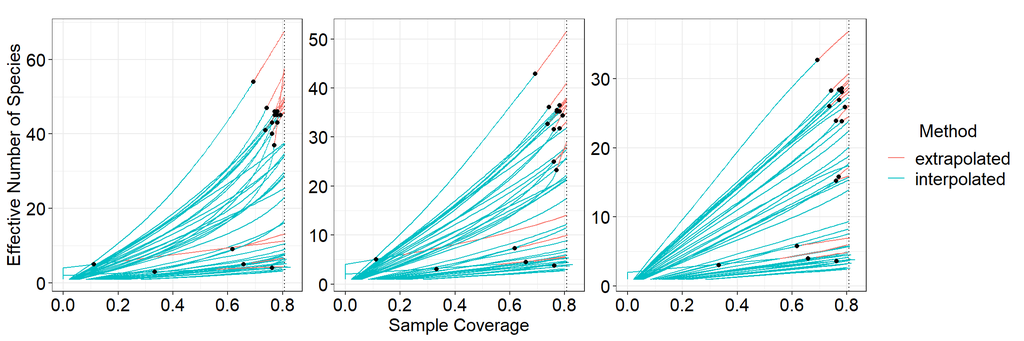

```r
ggplot()+
  geom_line(data= subset(h, method!="observed"),
            aes(x=SC, y=qD, colour=method, group=Sample))+
  geom_point(data= subset(h, method=="observed"),
             aes(x=SC, y=qD, group=Sample))+
  geom_vline(xintercept = c(0.807), linetype=3)+
  facet_wrap(~order, scale="free")+
  labs(x = "Sample Coverage", y = "Effective Number of Species",
       colour="Method")+
  theme_bw()%+replace% large %+replace% no_strip
```

Fig. X. Coverage-based Diversity accumulation curves based on species richness (left), exponential Shannon (middle) and inversed Simpson indices (right) from surface. The blue lines indicate the interpolated (rarefied) and red lines indicate extrapolated parts of the accumulation curves based on 1000 permutations. Dotted symbols indicate the observed diversity values. Sample size (numbers of individuals) and the Hill numbers are cut off by 80.7% sample coverage. The Hill numbers of order q = 2 (inversed Simpson) for sample “OR1_1126_GC2_1_9_3” can not be properly estimated and thus were eliminated.

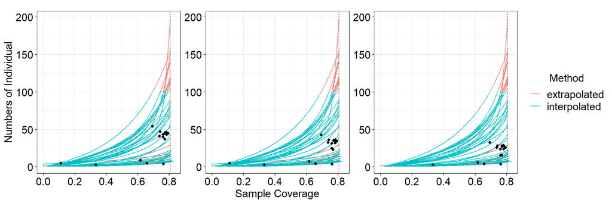

```r
ggplot()+
  geom_line(data= subset(h, method!="observed"),
            aes(x=SC, y=m, colour=method, group=Sample))+
  geom_point(data= subset(h, method=="observed"),
             aes(x=SC, y=qD, group=Sample))+
  geom_vline(xintercept = c(0.807), linetype=3)+
  facet_wrap(~order, scale="free")+
  labs(x = "Sample Coverage", y = "Numbers of Individual",
       colour="Method")+
  theme_bw()%+replace% large %+replace% no_strip
```

Fig. X. Sample size as a function of sample coverage based on species richness (left), exponential Shannon (middle) and inversed Simpson indices (right) from surface. The blue lines indicate the interpolated (rarefied) and red lines indicate extrapolated parts of the accumulation curves based on 1000 permutations. Dotted symbols indicate the observed diversity values. Sample size (numbers of individuals) and the Hill numbers are cut off by 80.7% sample coverage. The Hill numbers of order q = 2 (inversed Simpson) for sample “OR1_1126_GC2_1_9_3” can not be properly estimated and thus were eliminated.

```r
# ~80.7% sample coverage
#h0 <- lapply(q0$iNextEst, FUN=function(x) {
#  d<-abs(x$SC-0.807)
#  o <- subset(x, d==min(d))
#  o[dim(o)[1],]
#  }) %>% ldply(.id="Sample")
#round(mean(h0$SC), 3)

#h1 <- lapply(q1$iNextEst, FUN=function(x) {
#  d<-abs(x$SC-0.807)
#  o <- subset(x, d==min(d))
#  o[dim(o)[1],]
#  }) %>% ldply(.id="Sample")
#round(mean(h1$SC), 3)

#h2 <- lapply(q2$iNextEst, FUN=function(x) {
#  d<-abs(x$SC-0.807)
#  o <- subset(x, d==min(d))
#  o[dim(o)[1],]
#  }) %>% ldply(.id="Sample")
# Set the bad diversity estimates to NA
#h2[h2$Sample == "OR1_1126_GC2_1_9_3", c("qD", "qD.LCL", "qD.UCL", "SC", "SC.LCL", "SC.UCL")] <- NA
#round(mean(h2$SC, na.rm=TRUE), 3)

# 100 randomly selected individual
h0 <- subset(ldply(q0$iNextEst, .id="Sample"), m==100)
h1 <- subset(ldply(q1$iNextEst, .id="Sample"), m==100)
h2 <- subset(ldply(q2$iNextEst, .id="Sample"), m==100)
# Set the bad diversity estimates to NA
h2[h2$Sample == "OR1_1126_GC2_1_9_2"|h2$Sample == "OR1_1126_GC2_1_9_3", c("qD", "qD.LCL", "qD.UCL", "SC", "SC.LCL", "SC.UCL")] <- NA
```

## q=0 or species richness

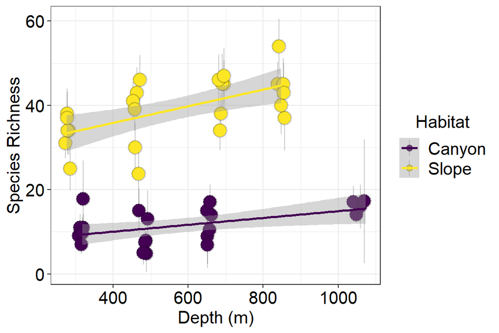

```r
ggplot(data=cbind(h0, e),
       aes(x=Depth, y=qD, ymin=qD.LCL, ymax=qD.UCL, colour=Habitat))+
  geom_pointrange(aes(fill=Habitat), pch=21, colour=gray(0, 0.2), fatten = 10,
                  position=position_jitter(width=10))+
  stat_smooth(method="lm", fill="gray60")+
  labs(x="Depth (m)", y="Species Richness")+
  scale_fill_viridis(discrete = TRUE)+
  scale_color_viridis(discrete = TRUE)+
  theme_bw() %+replace% large
```

```r
# Linear regression
hl <- splitBy(~Habitat, subset(cbind(h0, e), Sample!="OR1_1126_GC2_1_9_3"))
lapply(hl, FUN=function(x)summary(lm(qD~Depth, data=x)))
```

```
## $Canyon
##
## Call:
## lm(formula = qD ~ Depth, data = x)
##
## Residuals:
##     Min      1Q  Median      3Q     Max
## -5.7965 -2.7399  0.4091  1.7711  8.4851
##
## Coefficients:
##             Estimate Std. Error t value Pr(>|t|)
## (Intercept) 6.593397   2.063931   3.195  0.00477 **
## Depth       0.008288   0.003187   2.600  0.01758 *
## ---
## Signif. codes:  0 '***' 0.001 '**' 0.01 '*' 0.05 '.' 0.1 ' ' 1
##
## Residual standard error: 3.769 on 19 degrees of freedom
## Multiple R-squared:  0.2625, Adjusted R-squared:  0.2236
## F-statistic: 6.761 on 1 and 19 DF,  p-value: 0.01758
##
##
## $Slope
##
## Call:
## lm(formula = qD ~ Depth, data = x)
##
## Residuals:
##      Min       1Q   Median       3Q      Max
## -13.3692  -3.8583   0.5521   4.0311   9.3031
##
## Coefficients:
##              Estimate Std. Error t value Pr(>|t|)
## (Intercept) 27.961517   3.431116   8.149 4.34e-08 ***
## Depth        0.019735   0.005629   3.506  0.00199 **
## ---
## Signif. codes:  0 '***' 0.001 '**' 0.01 '*' 0.05 '.' 0.1 ' ' 1
##
## Residual standard error: 5.986 on 22 degrees of freedom
## Multiple R-squared:  0.3585, Adjusted R-squared:  0.3293
## F-statistic: 12.29 on 1 and 22 DF,  p-value: 0.001994
```

```r
# Linear Mixed-Effects Models
f <- lme(fixed = qD ~ Habitat*Depth, random = ~1|Cruise, data=cbind(h0, e), method = "REML", weights=varIdent(form=~1|Cruise))
summary(f)
```

```
## Linear mixed-effects model fit by REML
##  Data: cbind(h0, e)
##        AIC      BIC    logLik
##   300.8525 313.0162 -143.4263
##
## Random effects:
##  Formula: ~1 | Cruise
##         (Intercept) Residual
## StdDev:    2.085732 4.719927
##
## Variance function:
##  Structure: Different standard deviations per stratum
##  Formula: ~1 | Cruise
##  Parameter estimates:
## OR1_1114 OR1_1126
## 1.000000 1.032195
## Fixed effects: qD ~ Habitat * Depth
##                        Value Std.Error DF  t-value p-value
## (Intercept)         7.140348  2.978302 41 2.397456  0.0211
## HabitatSlope       20.745407  3.775351 41 5.494961  0.0000
## Depth               0.007325  0.004039 41 1.813730  0.0770
## HabitatSlope:Depth  0.012587  0.006052 41 2.079642  0.0439
##  Correlation:
##                    (Intr) HbttSl Depth
## HabitatSlope       -0.596
## Depth              -0.798  0.630
## HabitatSlope:Depth  0.532 -0.927 -0.667
##
## Standardized Within-Group Residuals:
##          Min           Q1          Med           Q3          Max
## -3.115059456 -0.647997028  0.007026726  0.657511038  1.964736658
##
## Number of Observations: 46
## Number of Groups: 2
```

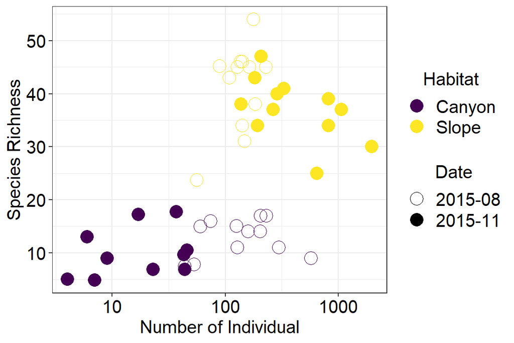

```r
out <- cbind(h0, Abund=nema_total$Abundance,e)
out$Date <- factor(out$Cruise, labels=c("2015-08", "2015-11"))
ggplot(data=out, aes(x=Abund, y=qD, colour=Habitat, shape=Date))+
  geom_point(size=5)+
  labs(x="Number of Individual", y="Species Richness")+
  scale_shape_manual(values=c(1, 19))+
  scale_x_log10()+
  scale_color_viridis(discrete = TRUE)+
  theme_bw() %+replace% large
```

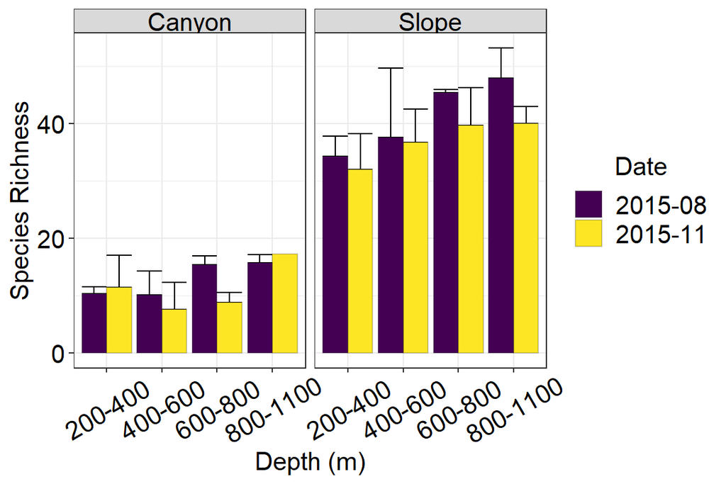

```r
out <- summaryBy(qD~Cruise+Station+Habitat+Zone, data=cbind(h0, e), FUN=c(mean, sd))
out$Date <- factor(out$Cruise, labels=c("2015-08", "2015-11"))
names(out)[5:6] <- c("qD", "sd")

ggplot(data=out, aes(x=Zone, y=qD, ymin=qD, ymax=qD+sd, fill=Date))+
  geom_errorbar(position="dodge")+
  geom_bar(stat="identity", position="dodge", colour=gray(0, 0.2))+
  facet_wrap(~Habitat)+
  labs(x="Depth (m)", y="Species Richness")+
  scale_fill_viridis(discrete = TRUE)+
  scale_color_viridis(discrete = TRUE)+
  theme_bw() %+replace% large %+replace% theme(axis.text.x=element_text(angle=30))
```

## q=1 or exponential Shannon diversity

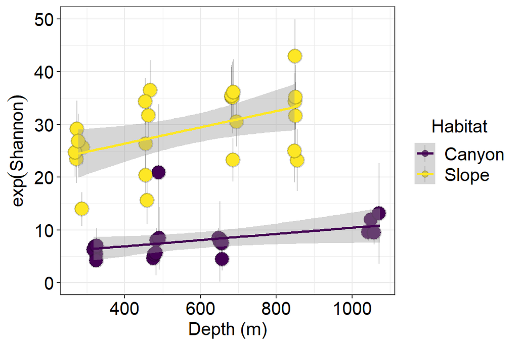

```r
ggplot(data=cbind(h1, e),
       aes(x=Depth, y=qD, ymin=qD.LCL, ymax=qD.UCL, colour=Habitat))+
  geom_pointrange(aes(fill=Habitat), pch=21, colour=gray(0, 0.2), fatten = 10,
                  position=position_jitter(width=10))+
  stat_smooth(method="lm", fill="gray60")+
  labs(x="Depth (m)", y=expression(exp(Shannon)))+
  scale_fill_viridis(discrete = TRUE)+
  scale_color_viridis(discrete = TRUE)+
  theme_bw() %+replace% large
```

```r
# Linear regression
hl <- splitBy(~Habitat, cbind(h1, e))
lapply(hl, FUN=function(x)summary(lm(qD~Depth, data=x)))
```

```
## $Canyon
##
## Call:
## lm(formula = qD ~ Depth, data = x)
##
## Residuals:
##     Min      1Q  Median      3Q     Max
## -3.9607 -1.2442 -0.4308  0.4856 13.4633
##
## Coefficients:
##             Estimate Std. Error t value Pr(>|t|)
## (Intercept) 4.588199   1.840743   2.493   0.0216 *
## Depth       0.005851   0.002871   2.038   0.0550 .
## ---
## Signif. codes:  0 '***' 0.001 '**' 0.01 '*' 0.05 '.' 0.1 ' ' 1
##
## Residual standard error: 3.409 on 20 degrees of freedom
## Multiple R-squared:  0.172,  Adjusted R-squared:  0.1305
## F-statistic: 4.153 on 1 and 20 DF,  p-value: 0.055
##
##
## $Slope
##
## Call:
## lm(formula = qD ~ Depth, data = x)
##
## Residuals:
##     Min      1Q  Median      3Q     Max
## -11.740  -3.067   1.063   4.430   9.595
##
## Coefficients:
##              Estimate Std. Error t value Pr(>|t|)
## (Intercept) 20.205926   3.656481   5.526 1.49e-05 ***
## Depth        0.015453   0.005998   2.576   0.0172 *
## ---
## Signif. codes:  0 '***' 0.001 '**' 0.01 '*' 0.05 '.' 0.1 ' ' 1
##
## Residual standard error: 6.379 on 22 degrees of freedom
## Multiple R-squared:  0.2318, Adjusted R-squared:  0.1968
## F-statistic: 6.637 on 1 and 22 DF,  p-value: 0.01723
```

```r
# Linear Mixed-Effects Models
f <- lme(fixed = qD ~ Habitat*Depth, random = ~1|Cruise, data=subset(cbind(h1, e), Sample!="OR1_1126_GC2_1_9_3"), method = "REML", weights=varIdent(form=~1|Cruise))
summary(f)
```

```
## Linear mixed-effects model fit by REML
##  Data: subset(cbind(h1, e), Sample != "OR1_1126_GC2_1_9_3")
##        AIC      BIC    logLik
##   290.5304 302.5254 -138.2652
##
## Random effects:
##  Formula: ~1 | Cruise
##         (Intercept) Residual
## StdDev:    1.825105 4.151748
##
## Variance function:
##  Structure: Different standard deviations per stratum
##  Formula: ~1 | Cruise
##  Parameter estimates:
## OR1_1114 OR1_1126
## 1.000000 1.218036
## Fixed effects: qD ~ Habitat * Depth
##                        Value Std.Error DF  t-value p-value
## (Intercept)         3.391525  2.765389 40 1.226419  0.2272
## HabitatSlope       16.422579  3.572048 40 4.597525  0.0000
## Depth               0.006167  0.003744 40 1.647081  0.1074
## HabitatSlope:Depth  0.010499  0.005677 40 1.849202  0.0718
##  Correlation:
##                    (Intr) HbttSl Depth
## HabitatSlope       -0.605
## Depth              -0.808  0.628
## HabitatSlope:Depth  0.533 -0.926 -0.659
##
## Standardized Within-Group Residuals:
##         Min          Q1         Med          Q3         Max
## -3.14151423 -0.34465649  0.02732843  0.62581086  1.88461858
##
## Number of Observations: 45
## Number of Groups: 2
```

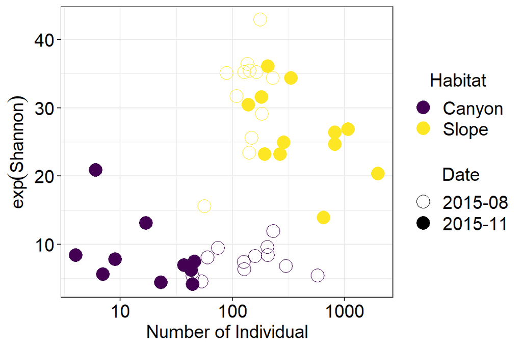

```r
out <- cbind(h1, Abund=nema_total$Abundance,e)
out$Date <- factor(out$Cruise, labels=c("2015-08", "2015-11"))
ggplot(data=out, aes(x=Abund, y=qD, colour=Habitat, shape=Date))+
  geom_point(size=5)+
  labs(x="Number of Individual", y=expression(exp(Shannon)))+
  scale_shape_manual(values=c(1, 19))+
  scale_x_log10()+
  scale_color_viridis(discrete = TRUE)+
  theme_bw() %+replace% large
```

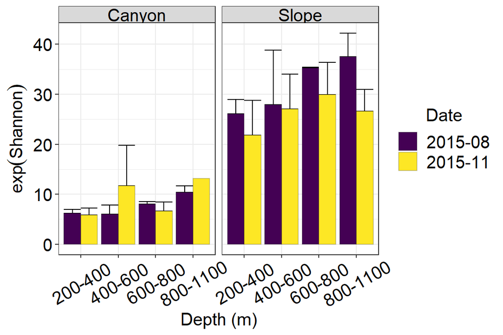

```r
out <- summaryBy(qD~Cruise+Station+Habitat+Zone, data=cbind(h1, e), FUN=c(mean, sd))
out$Date <- factor(out$Cruise, labels=c("2015-08", "2015-11"))
names(out)[5:6] <- c("qD", "sd")

ggplot(data=out, aes(x=Zone, y=qD, ymin=qD, ymax=qD+sd, fill=Date))+
  geom_errorbar(position="dodge")+
  geom_bar(stat="identity", position="dodge", colour=gray(0, 0.2))+
  facet_wrap(~Habitat)+
  labs(x="Depth (m)", y=expression(exp(Shannon)))+
  scale_fill_viridis(discrete = TRUE)+
  scale_color_viridis(discrete = TRUE)+
  theme_bw() %+replace% large %+replace% theme(axis.text.x=element_text(angle=30))
```

## q=2 or inverse Simpson diversity

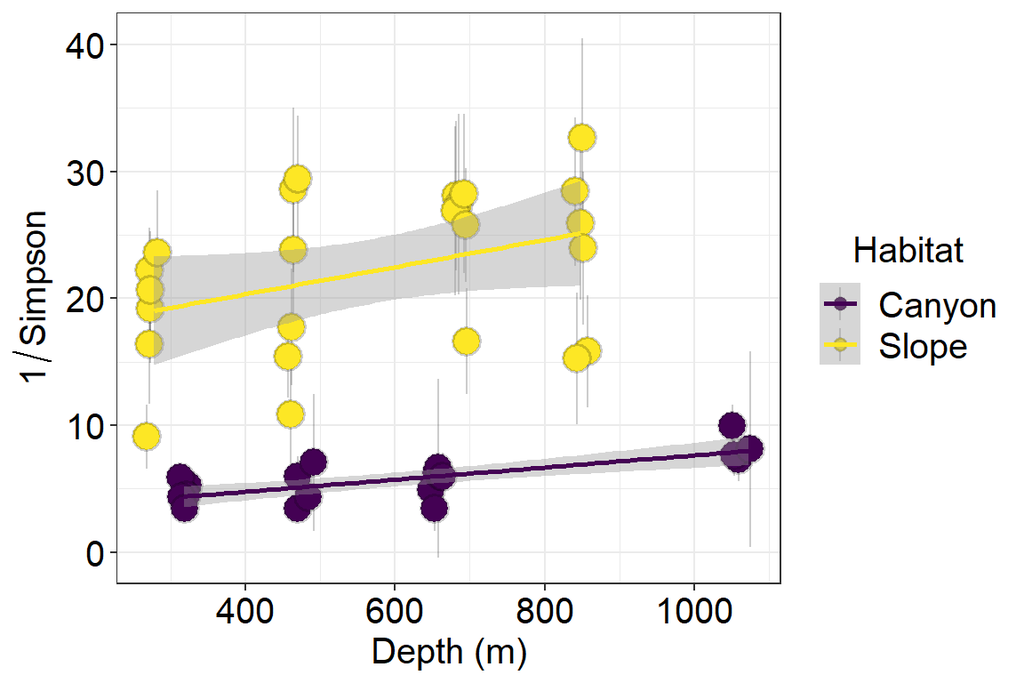

```r
ggplot(data=cbind(h2, e),
       aes(x=Depth, y=qD, ymin=qD.LCL, ymax=qD.UCL, colour=Habitat))+
  geom_pointrange(aes(fill=Habitat), pch=21, colour=gray(0, 0.2), fatten = 10,
                  position=position_jitter(width=10))+
  stat_smooth(method="lm", fill="gray60")+
  labs(x="Depth (m)", y=expression(1/Simpson))+
  scale_fill_viridis(discrete = TRUE)+
  scale_color_viridis(discrete = TRUE)+
  theme_bw() %+replace% large
```

```r
# Linear regression
hl <- splitBy(~Habitat, cbind(h1, e))
lapply(hl, FUN=function(x)summary(lm(qD~Depth, data=x)))
```

```
## $Canyon
##
## Call:
## lm(formula = qD ~ Depth, data = x)
##
## Residuals:
##     Min      1Q  Median      3Q     Max
## -3.9607 -1.2442 -0.4308  0.4856 13.4633
##
## Coefficients:
##             Estimate Std. Error t value Pr(>|t|)
## (Intercept) 4.588199   1.840743   2.493   0.0216 *
## Depth       0.005851   0.002871   2.038   0.0550 .
## ---
## Signif. codes:  0 '***' 0.001 '**' 0.01 '*' 0.05 '.' 0.1 ' ' 1
##
## Residual standard error: 3.409 on 20 degrees of freedom
## Multiple R-squared:  0.172,  Adjusted R-squared:  0.1305
## F-statistic: 4.153 on 1 and 20 DF,  p-value: 0.055
##
##
## $Slope
##
## Call:
## lm(formula = qD ~ Depth, data = x)
##
## Residuals:
##     Min      1Q  Median      3Q     Max
## -11.740  -3.067   1.063   4.430   9.595
##
## Coefficients:
##              Estimate Std. Error t value Pr(>|t|)
## (Intercept) 20.205926   3.656481   5.526 1.49e-05 ***
## Depth        0.015453   0.005998   2.576   0.0172 *
## ---
## Signif. codes:  0 '***' 0.001 '**' 0.01 '*' 0.05 '.' 0.1 ' ' 1
##
## Residual standard error: 6.379 on 22 degrees of freedom
## Multiple R-squared:  0.2318, Adjusted R-squared:  0.1968
## F-statistic: 6.637 on 1 and 22 DF,  p-value: 0.01723
```

```r
# Linear Mixed-Effects Models
f <- lme(fixed = qD ~ Habitat*Depth, random = ~1|Cruise, data=cbind(h2, e), method = "REML", weights=varIdent(form=~1|Cruise), na.action = na.omit)
summary(f)
```

```
## Linear mixed-effects model fit by REML
##  Data: cbind(h2, e)
##        AIC      BIC    logLik
##   278.9082 290.7304 -132.4541
##
## Random effects:
##  Formula: ~1 | Cruise
##         (Intercept) Residual
## StdDev:    1.759115 3.591328
##
## Variance function:
##  Structure: Different standard deviations per stratum
##  Formula: ~1 | Cruise
##  Parameter estimates:
## OR1_1114 OR1_1126
## 1.000000 1.434306
## Fixed effects: qD ~ Habitat * Depth
##                        Value Std.Error DF  t-value p-value
## (Intercept)         2.567486  2.570541 39 0.998811  0.3240
## HabitatSlope       12.838257  3.276532 39 3.918245  0.0003
## Depth               0.004393  0.003375 39 1.301535  0.2007
## HabitatSlope:Depth  0.008260  0.005172 39 1.597063  0.1183
##  Correlation:
##                    (Intr) HbttSl Depth
## HabitatSlope       -0.596
## Depth              -0.793  0.626
## HabitatSlope:Depth  0.517 -0.925 -0.653
##
## Standardized Within-Group Residuals:
##        Min         Q1        Med         Q3        Max
## -3.2102876 -0.3764404  0.1558663  0.4783100  1.7931746
##
## Number of Observations: 44
## Number of Groups: 2
```

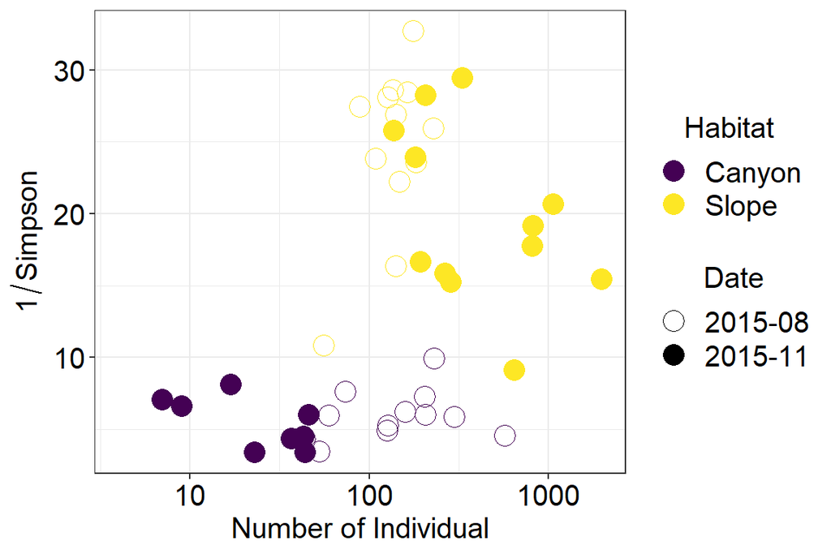

```r
out <- cbind(h2, Abund=nema_total$Abundance,e)
out$Date <- factor(out$Cruise, labels=c("2015-08", "2015-11"))
ggplot(data=out, aes(x=Abund, y=qD, colour=Habitat, shape=Date))+
  geom_point(size=5)+
  labs(x="Number of Individual", y=expression(1/Simpson))+
  scale_shape_manual(values=c(1, 19))+
  scale_x_log10()+
  scale_color_viridis(discrete = TRUE)+
  theme_bw() %+replace% large
```

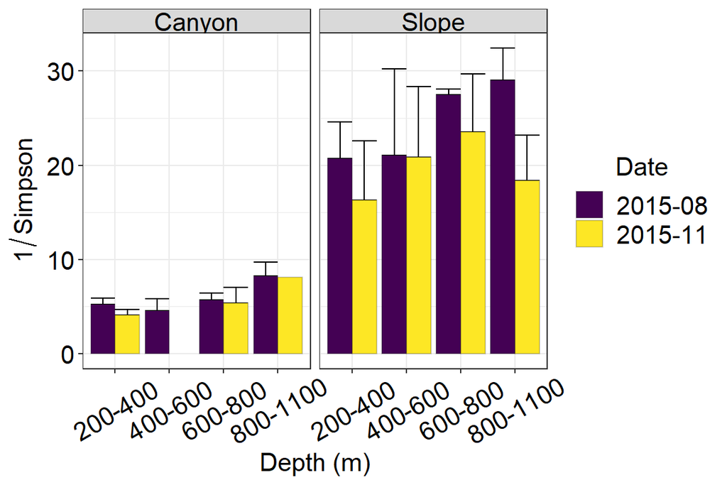

```r
out <- summaryBy(qD~Cruise+Station+Habitat+Zone, data=cbind(h2, e), FUN=c(mean, sd))
out$Date <- factor(out$Cruise, labels=c("2015-08", "2015-11"))
names(out)[5:6] <- c("qD", "sd")

ggplot(data=out, aes(x=Zone, y=qD, ymin=qD, ymax=qD+sd, fill=Date))+
  geom_errorbar(position="dodge")+
  geom_bar(stat="identity", position="dodge", colour=gray(0, 0.2))+
  facet_wrap(~Habitat)+
  labs(x="Depth (m)", y=expression(1/Simpson))+
  scale_fill_viridis(discrete = TRUE)+
  scale_color_viridis(discrete = TRUE)+
  theme_bw() %+replace% large %+replace% theme(axis.text.x=element_text(angle=30))
```

# Correlation bettwen exponential Shannon (q=1) and environmental factor

```r
p1 <- ggplot(data=cbind(h1, e),
       aes(x=Speed, y=qD, ymin=qD.LCL, ymax=qD.UCL))+
  geom_pointrange(aes(fill=Habitat), pch=21, colour=gray(0, 0.2), fatten=10)+
  stat_smooth(method="lm", fill="gray60", colour="gray50")+
  labs(x="Modeled Current Velocity (m/s)", y="Species Diversity")+
  scale_fill_viridis(discrete = TRUE)+
  scale_color_viridis(discrete = TRUE)+
  theme_bw() %+replace% large %+replace% theme(legend.position="none")

cor.test(formula=~qD+Speed, data=cbind(h1, e))
```

```
##
##  Pearson's product-moment correlation
##
## data:  qD and Speed
## t = -8.7034, df = 44, p-value = 4.035e-11
## alternative hypothesis: true correlation is not equal to 0
## 95 percent confidence interval:
##  -0.8819973 -0.6566535
## sample estimates:
##        cor
## -0.7953397
```

```r
p2 <- ggplot(data=cbind(h1, e),
       aes(x=over20, y=qD, ymin=qD.LCL, ymax=qD.UCL))+
  geom_pointrange(aes(fill=Habitat), pch=21, colour=gray(0, 0.2), fatten=10)+
  stat_smooth(method="lm", fill="gray60", colour="gray50")+
  labs(x="Modeled Duration of Erosion (hr)", y="Species Diversity")+
  scale_fill_viridis(discrete = TRUE)+
  scale_color_viridis(discrete = TRUE)+
  theme_bw() %+replace% large %+replace% theme(legend.position="none")

cor.test(formula=~qD+over20, data=cbind(h1, e))
```

```
##
##  Pearson's product-moment correlation
##
## data:  qD and over20
## t = -5.6529, df = 44, p-value = 1.09e-06
## alternative hypothesis: true correlation is not equal to 0
## 95 percent confidence interval:
##  -0.7901420 -0.4414466
## sample estimates:
##        cor
## -0.6486229
```

```r
p3 <- ggplot(data=cbind(h1, e),
       aes(x=transmissometer, y=qD, ymin=qD.LCL, ymax=qD.UCL))+
  geom_pointrange(aes(fill=Habitat), pch=21, colour=gray(0, 0.2), fatten=10)+
  stat_smooth(method="lm", fill="gray60", colour="gray50")+
  labs(x="Light Transmission (%)", y="Species Diversity")+
  scale_fill_viridis(discrete = TRUE)+
  scale_color_viridis(discrete = TRUE)+
  theme_bw() %+replace% large %+replace% theme(legend.position="none")

cor.test(formula=~qD+transmissometer, data=cbind(h1, e))
```

```
##
##  Pearson's product-moment correlation
##
## data:  qD and transmissometer
## t = 9.0336, df = 44, p-value = 1.394e-11
## alternative hypothesis: true correlation is not equal to 0
## 95 percent confidence interval:
##  0.6732844 0.8884481
## sample estimates:
##       cor
## 0.8060395
```

```r
p4 <- ggplot(data=cbind(h1, e),
       aes(x=TOC, y=qD, ymin=qD.LCL, ymax=qD.UCL))+
  geom_pointrange(aes(fill=Habitat), pch=21, colour=gray(0, 0.2), fatten=10)+
  stat_smooth(method="lm", fill="gray60", colour="gray50")+
  labs(x="Total Organic Carbon (%)", y="Species Diversity")+
  scale_fill_viridis(discrete = TRUE)+
  scale_color_viridis(discrete = TRUE)+
  theme_bw() %+replace% large %+replace% theme(legend.position="none")

cor.test(formula=~qD+TOC, data=cbind(h1, e))
```

```
##
##  Pearson's product-moment correlation
##
## data:  qD and TOC
## t = 8.4144, df = 44, p-value = 1.033e-10
## alternative hypothesis: true correlation is not equal to 0
## 95 percent confidence interval:
##  0.6412038 0.8759281
## sample estimates:
##       cor
## 0.7853219
```

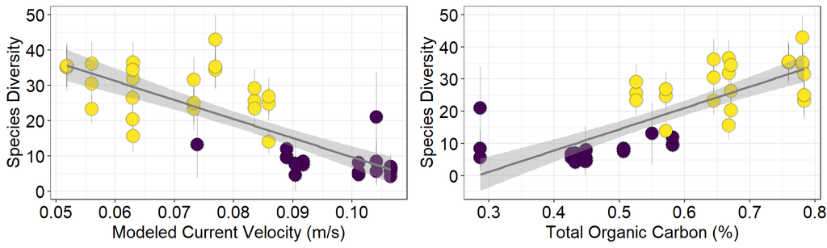

```r
plot_grid(p1, p4, ncol=2, align = "h", axis="b")
```

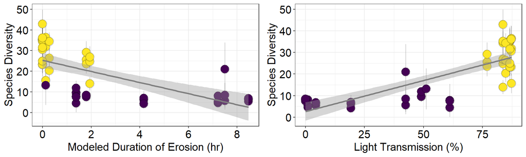

```r
plot_grid(p2, p3, ncol=2, align = "h", axis="b")
```

```r
out <- cbind(e[, 1:5], q0$DataInfo[,2:4], "0D"=h0$qD, "1D" = h1$qD, "2D"=h2$qD)
row.names(out) <- NULL
# Outliers, the confidence interval too large
out[out$Cruise=="OR1_1126" & out$Station=="GC2" & out$Subcore == 2, c("2D")] <- NA
out[out$Cruise=="OR1_1126" & out$Station=="GC2" & out$Subcore == 3, c("1D", "2D")] <- NA
kable(out)
```

| Cruise | Station | Deployment | Tube | Subcore | n | S.obs | SC | 0D | 1D | 2D |
| --- | --- | --- | --- | --- | --- | --- | --- | --- | --- | --- |
| OR1_1114 | GC1 | 2 | 11 | 1 | 100 | 11 | 0.9602 | 11.000 | 6.375 | 5.241 |
| OR1_1114 | GC1 | 2 | 11 | 2 | 100 | 9 | 0.9802 | 9.000 | 5.416 | 4.525 |
| OR1_1114 | GC1 | 2 | 11 | 3 | 100 | 11 | 0.9602 | 11.000 | 6.813 | 5.828 |
| OR1_1114 | GC2 | 1 | 1 | 1 | 53 | 7 | 0.9637 | 7.815 | 4.573 | 3.429 |
| OR1_1114 | GC2 | 1 | 1 | 2 | 43 | 7 | 0.9778 | 7.454 | 5.341 | 4.300 |
| OR1_1114 | GC2 | 1 | 1 | 3 | 55 | 12 | 0.9104 | 14.970 | 8.048 | 5.929 |
| OR1_1114 | GC3 | 1 | 3 | 1 | 100 | 14 | 0.9708 | 14.000 | 8.251 | 6.196 |
| OR1_1114 | GC3 | 1 | 3 | 2 | 100 | 15 | 0.9506 | 15.000 | 7.449 | 4.892 |
| OR1_1114 | GC3 | 1 | 3 | 3 | 100 | 17 | 0.9204 | 17.000 | 8.418 | 6.002 |
| OR1_1114 | GC4 | 1 | 6 | 1 | 100 | 14 | 0.9904 | 14.000 | 9.576 | 7.246 |
| OR1_1114 | GC4 | 1 | 6 | 2 | 74 | 14 | 0.9193 | 15.984 | 9.466 | 7.615 |
| OR1_1114 | GC4 | 1 | 6 | 3 | 100 | 17 | 0.9502 | 17.000 | 11.918 | 9.901 |
| OR1_1114 | GS1 | 1 | 2 | 1 | 100 | 31 | 0.9316 | 31.000 | 25.615 | 22.222 |
| OR1_1114 | GS1 | 1 | 2 | 2 | 100 | 38 | 0.8310 | 38.000 | 29.133 | 23.585 |
| OR1_1114 | GS1 | 1 | 2 | 3 | 100 | 34 | 0.8510 | 34.000 | 23.437 | 16.340 |
| OR1_1114 | GS2 | 1 | 2 | 1 | 100 | 46 | 0.7820 | 46.000 | 36.444 | 28.571 |
| OR1_1114 | GS2 | 1 | 2 | 2 | 49 | 18 | 0.8392 | 23.710 | 15.605 | 10.811 |
| OR1_1114 | GS2 | 1 | 2 | 3 | 100 | 43 | 0.7818 | 43.000 | 31.734 | 23.810 |
| OR1_1114 | GS3 | 1 | 6 | 1 | 100 | 45 | 0.7822 | 45.000 | 35.198 | 28.090 |
| OR1_1114 | GS3 | 1 | 6 | 2 | 83 | 41 | 0.7373 | 45.166 | 35.118 | 27.417 |
| OR1_1114 | GS3 | 1 | 6 | 3 | 100 | 46 | 0.7720 | 46.000 | 35.423 | 26.882 |
| OR1_1114 | GS4 | 1 | 4 | 1 | 100 | 45 | 0.7928 | 45.000 | 34.338 | 25.907 |
| OR1_1114 | GS4 | 1 | 4 | 2 | 100 | 54 | 0.6926 | 54.000 | 42.905 | 32.680 |
| OR1_1114 | GS4 | 1 | 4 | 3 | 100 | 45 | 0.7718 | 45.000 | 35.194 | 28.409 |
| OR1_1126 | GC1 | 1 | 11 | 1 | 43 | 9 | 0.9566 | 9.638 | 6.212 | 4.491 |
| OR1_1126 | GC1 | 1 | 11 | 2 | 37 | 10 | 0.8393 | 17.714 | 6.975 | 4.320 |
| OR1_1126 | GC1 | 1 | 11 | 3 | 44 | 6 | 0.9566 | 6.901 | 4.148 | 3.370 |
| OR1_1126 | GC2 | 1 | 9 | 1 | 6 | 4 | 0.7619 | 4.833 | 5.605 | 7.042 |
| OR1_1126 | GC2 | 1 | 9 | 2 | 3 | 3 | 0.3333 | 5.000 | 8.425 | NA |
| OR1_1126 | GC2 | 1 | 9 | 3 | 5 | 5 | 0.1111 | 13.000 | NA | NA |
| OR1_1126 | GC3 | 1 | 12 | 1 | 8 | 5 | 0.6576 | 8.937 | 7.796 | 6.604 |
| OR1_1126 | GC3 | 1 | 12 | 2 | 17 | 5 | 0.8893 | 6.870 | 4.460 | 3.403 |
| OR1_1126 | GC3 | 1 | 12 | 3 | 42 | 9 | 0.9535 | 10.470 | 7.470 | 5.969 |
| OR1_1126 | GC4 | 3 | 2 | 1 | 15 | 9 | 0.6182 | 17.239 | 13.129 | 8.121 |
| OR1_1126 | GS1 | 1 | 5 | 1 | 100 | 25 | 0.8806 | 25.000 | 13.939 | 9.107 |
| OR1_1126 | GS1 | 1 | 5 | 2 | 100 | 34 | 0.8510 | 34.000 | 24.706 | 19.157 |
| OR1_1126 | GS1 | 1 | 5 | 3 | 100 | 37 | 0.8210 | 37.000 | 26.850 | 20.661 |
| OR1_1126 | GS2 | 1 | 6 | 1 | 100 | 30 | 0.8606 | 30.000 | 20.326 | 15.432 |
| OR1_1126 | GS2 | 1 | 6 | 2 | 100 | 41 | 0.8622 | 41.000 | 34.362 | 29.412 |
| OR1_1126 | GS2 | 1 | 6 | 3 | 100 | 39 | 0.8326 | 39.000 | 26.366 | 17.730 |
| OR1_1126 | GS3 | 2 | 1 | 1 | 100 | 38 | 0.8514 | 38.000 | 30.473 | 25.773 |
| OR1_1126 | GS3 | 2 | 1 | 2 | 100 | 34 | 0.8620 | 34.000 | 23.236 | 16.611 |
| OR1_1126 | GS3 | 2 | 1 | 3 | 100 | 47 | 0.7418 | 47.000 | 36.096 | 28.249 |
| OR1_1126 | GS4 | 1 | 8 | 1 | 100 | 37 | 0.7704 | 37.000 | 23.199 | 15.823 |
| OR1_1126 | GS4 | 1 | 8 | 2 | 100 | 40 | 0.7612 | 40.000 | 24.938 | 15.244 |
| OR1_1126 | GS4 | 1 | 8 | 3 | 100 | 43 | 0.7610 | 43.000 | 31.565 | 23.923 |